# Creativity and Stereotypy Scores for Responses

# Loading in necessary tools and data:

```r
d <- readRDS("psychling/mapped_response_metadata_2025-05-25.rds")

library(dplyr)
library(tidyr)
library(purrr)
library(ggplot2)
library(ez)

library(pastecs)
library(psych)
library(tidyverse)
library(rstatix)
```

I used the code from “008-PsycholinguisticAnalysis” to make the data frame “filter_participants” that filters out any extreme values and extreme participants, which will be used to make the “norms_list”. The norms list will be used for assigning the creative and stereotypy scores.

```r
## Filter out responses faster than 250ms and responses that are more than
## 2.5 standard deviations away from participant mean. Also get rid of non-responses ########################

filter_participants <- d %>%
  filter(!participant %in% c("TTA_067","TTA_068")) %>%
  mutate(rt = rt *1000) %>%
  filter(rt > 250) |>
  filter(!Nletters == 0) |>
  group_by(participant) |>
  mutate(z_rt_pp = (rt - mean(rt))/sd(rt))|>
  filter(z_rt_pp < 2.5) |>
  ungroup() |>
  mutate(
    participant = as.factor(participant),
    condition = factor(condition, c("child", "peer", "short", "creative")),
    cue = factor(cue),
    response = str_trim(response)
  )
```

# Norms List

I am using the instructions from Fitzpatrick et al. 2013 for this, which is what Playfoot et al. 2016 used.

Firstly, I need to compile a full list of responses to the cue words and count up how many times each response was given for that cue. Then, I will need to order responses according to their frequency for that cue word, along with a record of that frequency.

I am only concerned with having cues and responses from the peer condition for the norms list. I filter for only rows with the condition ‘peer’ and I filter out any responses that are blank.

Now, for counting unique responses for that cue, I have to keep in mind that a response could be given for multiple cues (e.q. “fish” is given for both “barracuda” and “salmon”). So, when I mutate a new column to count the amount of unique responses for that given cue, I can’t just count how many times that response occurs in the response column; I have to take into account the cue that was being responded to.

So, for group_by, I am grouping by the cue-response pair. I then count the number of rows that exist for that pair with n() and mutate this to the column ‘frequency_response’. Now that I’ve confirmed that this works, I use distinct() to remove duplicate rows.

I ordered the df so that the response with the highest frequency is displayed for each cue.

And voila!!! I have a norms list which has the number of responses made for each cue.

#### 5/27/25 Edit:

I have added new columns to account for the revisions made. I have kept the original columns for comparison for how things have changed with the revisions.

There is now a corrected_response column that replaces any response that was corrected with it’s revision. This column will pretty much act as the response column has for the previous code. I have adapted the previous code to do what it has done with the uncorrected responses, but have assigned it to columns that have “corrected” in them.

This works by checking if the revision column contains a correction, and if so, replacing the original response with the correction. The reason why I added a separate column is to keep the original responses the participants made along with the correction made. I also filter out any lingering filler responses people made when they did not know a word.

```r
filter_participants_corrected <- filter_participants %>%
  mutate(corrected_response = ifelse((is.na(revision) != TRUE) & revision != "", revision, response),
         .after = revision) %>%
  filter(response != "") %>%
  filter(!is.na(response)) %>%
  filter(response != "notsure", response != "idk")


norms_list <- filter_participants_corrected %>%
  select(condition, cue, response, revision, corrected_response) %>%
  filter(condition == 'peer') %>%
  filter(!is.na(response)) %>%
  group_by(cue, response) %>%
  mutate(frequency_response = n()) %>%
  group_by(cue) %>%
  mutate(max_response = ifelse(frequency_response == max(frequency_response), TRUE, FALSE)) %>%
  group_by(cue, corrected_response) %>%
  mutate(frequency_corrected = n()) %>%
  group_by(cue) %>%
  mutate(max_corrected = ifelse(frequency_corrected == max(frequency_corrected), TRUE, FALSE)) %>%
  ungroup() %>%
  distinct() %>%
  arrange(cue, desc(frequency_response), desc(frequency_corrected))

# used for sanity check for norms_list
norms_list_corrected <- filter_participants %>%
  select(condition, cue, response, revision) %>%
  filter(condition == 'peer') %>%
  filter(response != "") %>%
  filter(response != "notsure", response != "idk") %>%
  filter(!is.na(response)) %>%
  mutate(corrected_response = ifelse((is.na(revision) != TRUE) & revision != "", revision, response),
         .after = revision) %>%
  group_by(cue, corrected_response) %>%
  mutate(frequency_corrected = n()) %>%
  distinct() %>%
  ungroup() %>%
  arrange(cue, desc(frequency_corrected))

norm_dic <- norms_list %>%
  select(cue,response, frequency_response, max_response)

norm_dic_corrected <- norms_list %>%
  select(cue, corrected_response, frequency_corrected, max_corrected) %>%
  distinct()
```

# Creative Scores

For the creative scores, a point is given if the response does not occur for that cue in the norms list.

I made a df that only includes the creative condition and takes out any blanks. In Playfoot, the creative scores were only given to the creative condition to compare stereotypy in the peer to creativity in the creative condition. The creative score is used to identify truly creative responses that are associated to the cue.

So, after I filter everything, I group by participant and cue (e.g. TTA_006, salmon). Then, I add a new column to assign the creative scores with a 0 for if the response to that cue in the creative list also occurs in the norms_dic, and a 1 if the response to that cue in the creative list does not occur in the norms_dic. If the response to the cue in the creative list (e.g. fish) is found for any response to the current cue we are on (c(pink, fish, etc) to salmon), then we get a 0. The bit of code at the bottom I am keeping for demonstration purposes only, just so you can see what data frame is being used.

#### 5/27 edit:

Here, I am implementing the corrected responses into this list and checking that it works before I add it to the data frames used for analysis.

```r
creative_list <- filter_participants_corrected %>%
  select(condition, participant, cue, response, corrected_response) %>%
  filter(condition == 'creative') %>%
  filter(response != "") %>%
  filter(response != "notsure", response != "idk", response != "notsre") %>%
  group_by(participant, cue) %>%
  mutate(creative_score = ifelse((response %in% norm_dic$response[cue == norm_dic$cue]), 0, 1)) %>%
  mutate(creative_score_corrected = ifelse(corrected_response %in%
                                             norm_dic_corrected$corrected_response[cue == norm_dic_corrected$cue],
                                           0,1)) %>%
  arrange(cue)
```

# Stereotypy Scores

There are a couple things that need to happen:

Firstly, one point is given if a response is the response most commonly given to the cue in the norms list.

Secondly, if a cue has more than one response that has an equal chance of being given, then a point is awarded for giving either response.

(***Third, only data from participants who responded >90% of the time were used.)

I grab each cue, and I want to evaluate what the highest frequency for a response is. Responses equal to that number for a cue get assigned a 1 and if not a 0. So, if a response for a cue is equal to the response for that cue with the highest frequency, assign that row a 1. If not, assign that row a zero. This also accounts for responses to a cue that have an equal number for the frequency_response.

Okay, so that works. Then, I grabbed the code from the norms_list and added the second section of code to it.

```r
#this gives me the highest frequency number for each cue.
norms_list %>%
  group_by(cue) %>%
  summarise(max(frequency_response))
```

| cue | max(frequency_response) |
| --- | --- |
| abhor | 6 |
| acronym | 7 |
| added | 6 |
| adored | 14 |
| apostle | 5 |
| arachnid | 19 |
| auditorium | 9 |
| barracuda | 15 |
| bits | 22 |
| breadth | 4 |

[output cut: 50 more lines]

```r
norms_list %>%
  group_by(cue) %>%
  summarise(max(frequency_corrected))
```

| cue | max(frequency_corrected) |
| --- | --- |
| abhor | 6 |
| acronym | 9 |
| added | 6 |
| adored | 14 |
| apostle | 5 |
| arachnid | 19 |
| auditorium | 9 |
| barracuda | 15 |
| bits | 24 |
| breadth | 4 |

[output cut: 50 more lines]

```r
#as.integer converts TRUE and FALSE to 1 and 0
norms_list %>%
  group_by(cue) %>%
  mutate(highest_frequency = as.integer(
    response %in% response[frequency_response == max(frequency_response, na.rm = TRUE)]))
```

| condition | cue | response | revision | corrected_response | frequency_response | max_response | frequency_corrected | max_corrected | highest_frequency |
| --- | --- | --- | --- | --- | --- | --- | --- | --- | --- |
| peer | abhor | hate | NA | hate | 6 | TRUE | 6 | TRUE | 1 |
| peer | abhor | habor | harbor | harbor | 1 | FALSE | 1 | FALSE | 0 |
| peer | abhor | gross | NA | gross | 1 | FALSE | 1 | FALSE | 0 |
| peer | abhor | shore | NA | shore | 1 | FALSE | 1 | FALSE | 0 |
| peer | abhor | anchor | NA | anchor | 1 | FALSE | 1 | FALSE | 0 |
| peer | abhor | hatred | NA | hatred | 1 | FALSE | 1 | FALSE | 0 |
| peer | abhor | adhere | NA | adhere | 1 | FALSE | 1 | FALSE | 0 |
| peer | acronym | synonym | NA | synonym | 7 | TRUE | 9 | TRUE | 1 |
| peer | acronym | words | NA | words | 4 | FALSE | 4 | FALSE | 0 |
| peer | acronym | abbreviation | NA | abbreviation | 3 | FALSE | 3 | FALSE | 0 |

[output cut: 809 more lines]

```r
#stereotypy scores for peer:
stereotypy_peer <- filter_participants %>%
  select(participant, cue, response, condition) %>%
  filter(condition == 'peer') %>%
  filter(response != "") %>%
  group_by(cue, response) %>%
  mutate(frequency_response = n()) %>%
  distinct() %>%
  ungroup() %>%
  arrange(participant, cue, desc(frequency_response)) %>%
  group_by(cue) %>%
  mutate(stereotypy_score = as.integer(
    response %in% response[frequency_response == max(frequency_response, na.rm = TRUE)])) %>%
  select(-condition, -frequency_response)
```

# Stereotypy and Creativity Scores for All Conditions

Averaging over participants within condition. Plotting average scores to see distribution of averages across conditions.

### Creative scores for all conditions

Since we used the peer condition as our reference for what responses to a cue are creative, the peer condition will not have any creative responses by default. However, Stan and I have gone in and changed it so if the response was made in the peer condition and the frequency of the response was 1, to give that response a 1 for being creative. This was reflected in a separate column called “c_score_peer”.

Every participant will have an average creativity score for all their responses, so I will count the amount of points each participant has accumulated. Since the scores are all 1’s and 0’s, I can just add all the creative scores for that participant and return the value. “creative_count” is the amount of creative responses a participant had. “creative_proportion” is the proportion of responses given that were creative (e.g. 20% (0.2) of the responses given by TTA_001 were creative).

#### Accounting for Revisions

In order to account for misspelled words being incorrectly reflected as creative, there is a separate series of columns that are “corrected”, which means they take into account the revisions made. See the description for how “filter_participants_corrected” was made to see how this is done.

```r
creative_all <- filter_participants_corrected %>%
  filter(response != "") %>%
  group_by(cue, response) %>%
  mutate(frequency_response = n(), .after = response) %>%
  group_by(cue) %>%
  mutate(max_response = ifelse(frequency_response == max(frequency_response), TRUE, FALSE),
         .after = frequency_response) %>%
  group_by(cue, corrected_response) %>%
  mutate(frequency_corrected = n(), .after = corrected_response) %>%
  group_by(cue) %>%
  mutate(max_corrected = ifelse(frequency_corrected == max(frequency_corrected), TRUE, FALSE),
         .after = frequency_corrected) %>%
  ungroup() %>%
  distinct() %>%
  arrange(cue, desc(frequency_response), desc(frequency_corrected)) %>%
  group_by(participant, cue) %>%
  mutate(creative_score = ifelse((response %in% norm_dic$response[cue == norm_dic$cue]), 0, 1),
         .after = response) %>%
  mutate(creative_score_corrected = ifelse(corrected_response %in%
                                             norm_dic_corrected$corrected_response[cue == norm_dic_corrected$cue],
                                           0,1),.after = corrected_response) %>%
  mutate(c_score_peer = ifelse((response %in% norm_dic$response[(cue == norm_dic$cue) &
                                                                  (norm_dic$frequency_response ==1)]),
                               1, 0),.after = response) %>%
  mutate(c_score_peer_corrected = ifelse((corrected_response %in% norm_dic_corrected$corrected_response[(cue == norm_dic_corrected$cue) & (norm_dic_corrected$frequency_corrected ==1)]), 1, 0), .after = corrected_response) %>%
  # this adds the count of creative responses per participant
  group_by(participant) %>%
  mutate(creative_count = ifelse(condition == "peer", sum(as.integer(c_score_peer)),
                                 sum(as.integer(creative_score))), .after = response) %>%
  mutate(creative_count_corrected = ifelse(condition == 'peer', sum(as.integer(c_score_peer_corrected)),
                                           sum(as.integer(creative_score_corrected))),
         .after = corrected_response) %>%
  #this adds the proportion of creative responses per participant
  mutate(creative_proportion = creative_count/60, .after = creative_count) %>%
  mutate(creative_proportion_c = creative_count_corrected/60, .after = creative_count_corrected) %>%
  ungroup() %>%
  select(c(-cue_onset:-key, -response.start, -response.stop))

# Count of creative scores for all conditions with peer as reference
creative_all %>%
  group_by(participant, condition) %>%
  count(creative_score)
```

| participant | condition | creative_score | n |
| --- | --- | --- | --- |
| TTA_001 | child | 0 | 48 |
| TTA_001 | child | 1 | 11 |
| TTA_002 | peer | 0 | 58 |
| TTA_003 | peer | 0 | 58 |
| TTA_004 | short | 0 | 32 |
| TTA_004 | short | 1 | 26 |
| TTA_005 | short | 0 | 38 |
| TTA_005 | short | 1 | 19 |
| TTA_006 | creative | 0 | 29 |
| TTA_006 | creative | 1 | 29 |

[output cut: 224 more lines]

```r
# Average creativity for each participant
creative_all %>%
  group_by(participant, condition) %>%
  filter(creative_score == 1) %>%
  count(creative_score)
```

| participant | condition | creative_score | n |
| --- | --- | --- | --- |
| TTA_001 | child | 1 | 11 |
| TTA_004 | short | 1 | 26 |
| TTA_005 | short | 1 | 19 |
| TTA_006 | creative | 1 | 29 |
| TTA_007 | creative | 1 | 21 |
| TTA_008 | child | 1 | 18 |
| TTA_009 | child | 1 | 13 |
| TTA_012 | short | 1 | 34 |
| TTA_013 | creative | 1 | 25 |
| TTA_014 | child | 1 | 24 |

[output cut: 90 more lines]

```r
NA
```

Here I am looking at the mean and sd for creative score per condition, their plots, an ANOVA, and it’s post-hoc.

```r
# Mean and SD for average creative score for each condition
creative_all %>%
  group_by(condition) %>%
  get_summary_stats(creative_score, type = "mean_sd")
```

| condition | variable | n | mean | sd |
| --- | --- | --- | --- | --- |
| child | creative_score | 1819 | 0.325 | 0.468 |
| peer | creative_score | 1788 | 0.000 | 0.000 |
| short | creative_score | 1769 | 0.383 | 0.486 |
| creative | creative_score | 1753 | 0.444 | 0.497 |

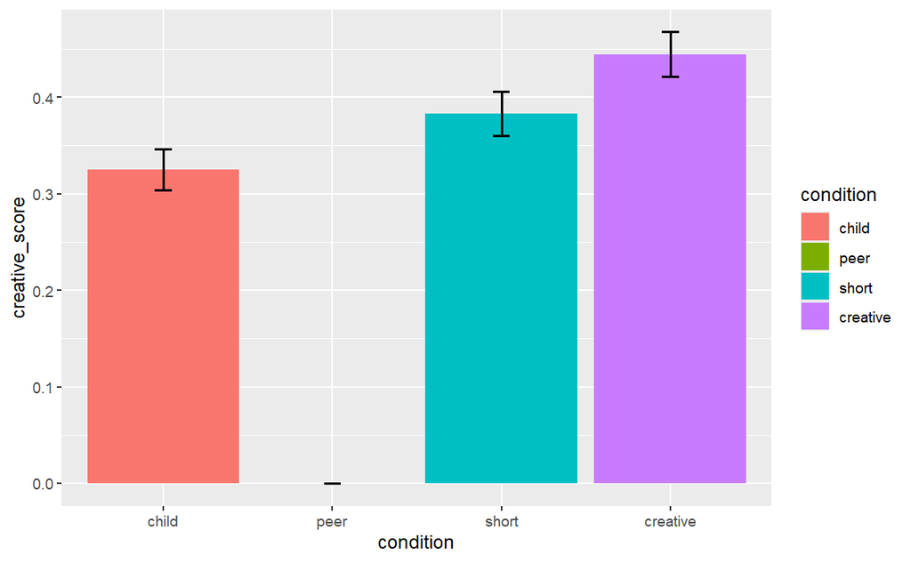

```r
# Plots for average count and proportion creative for each condition
ggplot(creative_all, aes(x = condition, y = creative_score, fill = condition)) +
  stat_summary(aes(y = creative_score), fun = "mean", geom = "bar") +
  stat_summary(fun.data = mean_cl_normal, geom = "errorbar", width = .1, linewidth = .75)
```

```r
# ANOVA's for creative count and proportion
c_score_model <- ezANOVA(data = creative_all,
                         dv = creative_score,
                         wid = participant,
                         between = condition,
                         detailed = TRUE)
c_score_model
```

|  | Effect | DFn | DFd | SSn | SSd | F | p | p<.05 | ges |
| --- | --- | --- | --- | --- | --- | --- | --- | --- | --- |
| 1 | condition | 3 | 130 | 3.963387 | 1.531895 | 112.114 | 6.795776e-36 | * | 0.7212346 |

```
$`Levene's Test for Homogeneity of Variance`
```

| DFn | DFd | SSn | SSd | F | p | p<.05 |
| --- | --- | --- | --- | --- | --- | --- |
| 3 | 130 | 0.2271534 | 0.6990883 | 14.08021 | 5.29053e-08 | * |

```r
pairwise.t.test(creative_all$creative_score, creative_all$condition, paired = FALSE)
```

```
    Pairwise comparisons using t tests with pooled SD

data:  creative_all$creative_score and creative_all$condition

         child   peer    short
peer     < 2e-16 -       -
short    3.6e-05 < 2e-16 -
creative < 2e-16 < 2e-16 2.5e-05

P value adjustment method: holm
```

### Stereotypy scores for all conditions

```r
stereotypy_all <- filter_participants_corrected %>%
  filter(response != "") %>%
  group_by(cue, response) %>%
  mutate(frequency_response = n(), .after = response) %>%
  arrange(participant, cue, desc(frequency_response)) %>%
  group_by(cue) %>%
  mutate(stereotypy_score = as.integer(
    response %in% norms_list$response[norms_list$max_response == TRUE & norms_list$cue %in% cue]),
    .after = response) %>%
  mutate(stereotypy_score_corrected = as.integer(
    corrected_response %in% norms_list$corrected_response[norms_list$max_corrected == TRUE &
                                                            norms_list$cue %in% cue]),
    .after = corrected_response) %>%
  # this adds the count of stereotypical responses per participant
  group_by(participant) %>%
  mutate(stereotypy_count = sum(as.integer(stereotypy_score == 1)), .after = response) %>%
  mutate(stereotypy_count_corrected = sum(as.integer(stereotypy_score_corrected == 1)),
         .after = corrected_response) %>%
  #this adds the proportion of stereotypical responses per participant
  mutate(stereotypy_proportion = stereotypy_count/60, .after = stereotypy_count) %>%
  mutate(stereotypy_proportion_c = stereotypy_count_corrected/60, .after = stereotypy_count_corrected) %>%
  select(c(-cue_onset:-key, -response.start, -response.stop))

# Counting how many stereotypical responses for each condition
stereotypy_all %>%
  group_by(condition) %>%
  count(stereotypy_score)
```

| condition | stereotypy_score | n |
| --- | --- | --- |
| child | 0 | 1158 |
| child | 1 | 661 |
| peer | 0 | 1030 |
| peer | 1 | 758 |
| short | 0 | 1199 |
| short | 1 | 570 |
| creative | 0 | 1274 |
| creative | 1 | 479 |

```r
# Average stereotypy for each participant
stereotypy_all %>%
  group_by(participant, condition) %>%
  filter(stereotypy_score == 1) %>%
  count(stereotypy_score)
```

| participant | condition | stereotypy_score | n |
| --- | --- | --- | --- |
| TTA_001 | child | 1 | 27 |
| TTA_002 | peer | 1 | 29 |
| TTA_003 | peer | 1 | 17 |
| TTA_004 | short | 1 | 16 |
| TTA_005 | short | 1 | 23 |
| TTA_006 | creative | 1 | 10 |
| TTA_007 | creative | 1 | 15 |
| TTA_008 | child | 1 | 14 |
| TTA_009 | child | 1 | 32 |
| TTA_010 | peer | 1 | 20 |

[output cut: 124 more lines]

```r
NA
```

Here I am looking at the mean and sd for stereotypy score, their plots, an ANOVA, and it’s post-hoc.

```r
# Mean and SD for average count and proportion stereotypy for each condition
stereotypy_all %>%
  group_by(condition) %>%
  get_summary_stats(stereotypy_score, type = "mean_sd")
```

| condition | variable | n | mean | sd |
| --- | --- | --- | --- | --- |
| child | stereotypy_score | 1819 | 0.363 | 0.481 |
| peer | stereotypy_score | 1788 | 0.424 | 0.494 |
| short | stereotypy_score | 1769 | 0.322 | 0.467 |
| creative | stereotypy_score | 1753 | 0.273 | 0.446 |

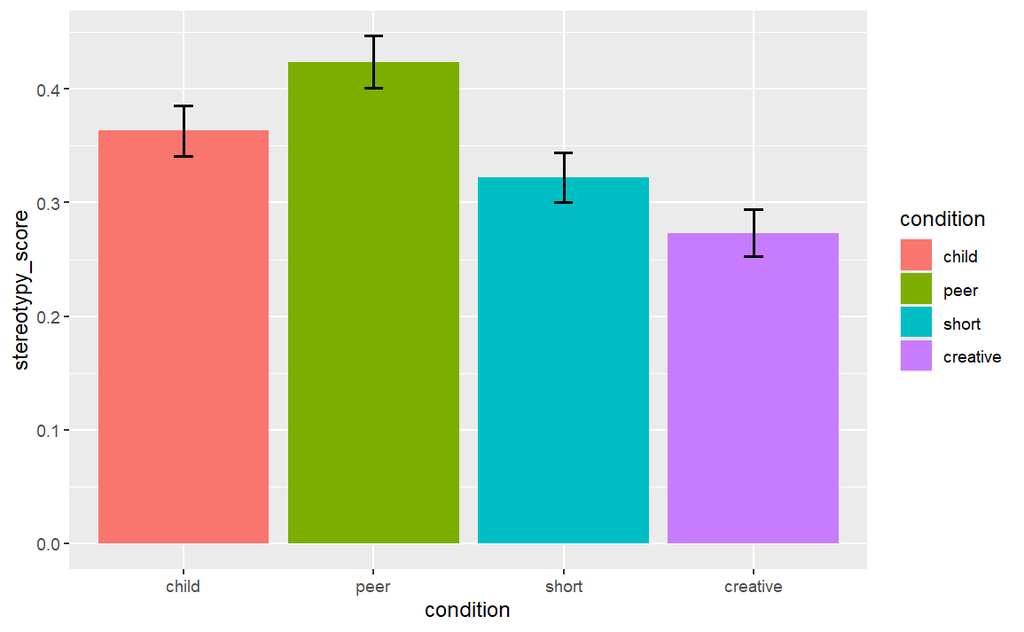

```r
# Plots for average count and proportion stereotypy for each condition
ggplot(stereotypy_all, aes(x = condition, y = stereotypy_score, fill = condition)) +
  stat_summary(aes(y = stereotypy_score), fun = "mean", geom = "bar") +
  stat_summary(fun.data = mean_cl_normal, geom = "errorbar", width = .1, linewidth = .75)
```

```r
# ANOVA's for stereotypy count and proportion
s_score_model <- ezANOVA(data = stereotypy_all,
                         dv = stereotypy_score,
                         wid = participant,
                         between = condition,
                         detailed = TRUE)
s_score_model
```

|  | Effect | DFn | DFd | SSn | SSd | F | p | p<.05 | ges |
| --- | --- | --- | --- | --- | --- | --- | --- | --- | --- |
| 1 | condition | 3 | 130 | 0.3969788 | 1.268514 | 13.56108 | 9.420818e-08 | * | 0.2383552 |

```
$`Levene's Test for Homogeneity of Variance`
```

| DFn | DFd | SSn | SSd | F | p | p<.05 |
| --- | --- | --- | --- | --- | --- | --- |
| 3 | 130 | 0.01736686 | 0.5181487 | 1.452409 | 0.2306283 |  |

```r
pairwise.t.test(stereotypy_all$stereotypy_score, stereotypy_all$condition, paired = FALSE)
```

```
    Pairwise comparisons using t tests with pooled SD

data:  stereotypy_all$stereotypy_score and stereotypy_all$condition

         child   peer    short
peer     0.00036 -       -
short    0.00912 7.4e-10 -
creative 5.0e-08 < 2e-16 0.00424

P value adjustment method: holm
```

### Average creative count and proportion for each participant per condition

“csonly” stands for creative score only. The “creative_csonly” data frame only has the unique score of the participant once. This helps with ensuring that the analysis ran is only counting each score once. When using the other data frame, there is an uneven number of observations for each participant, so their score has more/less instances than other participants.

```r
# DF with only the participant, their condition, and their scores
creative_csonly <- creative_all %>%
  select(c(participant, condition, creative_count, creative_proportion)) %>%
  distinct()

creative_csonly_corrected <- creative_all %>%
  select(c(participant, condition, creative_count_corrected, creative_proportion_c)) %>%
  distinct()

creative_csonly$condition = factor(creative_csonly$condition)

# Mean and SD for average count and proportion creative for each condition
creative_csonly %>%
  group_by(condition) %>%
  get_summary_stats(creative_count, type = "mean_sd")
```

| condition | variable | n | mean | sd |
| --- | --- | --- | --- | --- |
| child | creative_count | 34 | 17.382 | 5.716 |
| peer | creative_count | 34 | 17.588 | 5.188 |
| short | creative_count | 33 | 20.515 | 7.942 |
| creative | creative_count | 33 | 23.606 | 7.365 |

```r
creative_csonly %>%
  group_by(condition) %>%
  get_summary_stats(creative_proportion, type = "mean_sd")
```

| condition | variable | n | mean | sd |
| --- | --- | --- | --- | --- |
| child | creative_proportion | 34 | 0.290 | 0.095 |
| peer | creative_proportion | 34 | 0.293 | 0.086 |
| short | creative_proportion | 33 | 0.342 | 0.132 |
| creative | creative_proportion | 33 | 0.393 | 0.123 |

```r
# Mean and SD for average corrected count for each condition
creative_csonly_corrected %>%
  group_by(condition) %>%
  get_summary_stats(creative_count_corrected, type = "mean_sd")
```

| condition | variable | n | mean | sd |
| --- | --- | --- | --- | --- |
| child | creative_count_corrected | 34 | 16.941 | 5.404 |
| peer | creative_count_corrected | 34 | 16.706 | 5.306 |
| short | creative_count_corrected | 33 | 19.788 | 7.829 |
| creative | creative_count_corrected | 33 | 22.909 | 7.329 |

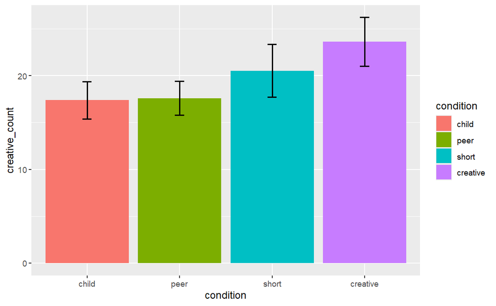

```r
# Plots for average count and proportion creative for each condition
ggplot(creative_csonly, aes(x = condition, y = creative_count, fill = condition)) +
  stat_summary(aes(y = creative_count), fun = "mean", geom = "bar") +
  stat_summary(fun.data = mean_cl_normal, geom = "errorbar", width = .1, linewidth = .75)
```

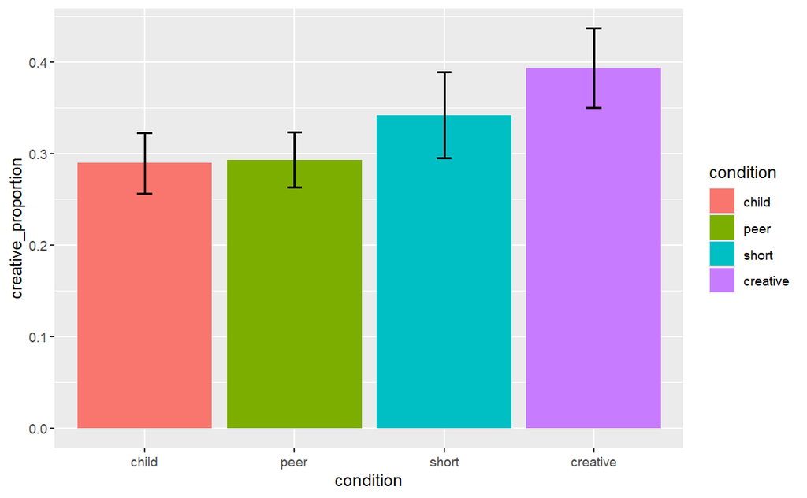

```r
ggplot(creative_csonly, aes(x = condition, y = creative_proportion, fill = condition)) +
  stat_summary(aes(y = creative_proportion), fun = "mean", geom = "bar") +
  stat_summary(fun.data = mean_cl_normal, geom = "errorbar", width = .1, linewidth = .75)
```

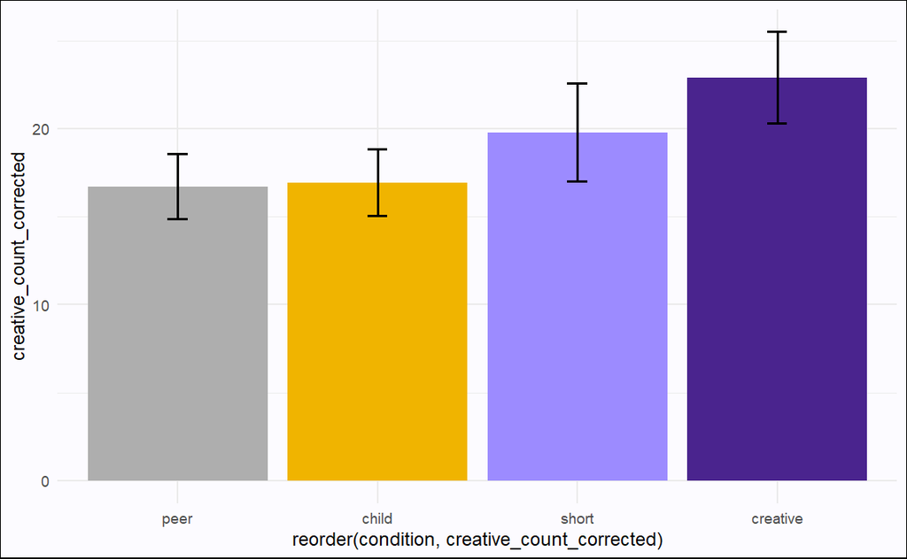

```r
# Plots for average corrected count for each condition
ggplot(creative_csonly_corrected, aes(x = reorder(condition, creative_count_corrected), y = creative_count_corrected, fill = condition)) +
  stat_summary(aes(y = creative_count_corrected), fun = "mean", geom = "bar") +
  stat_summary(fun.data = mean_cl_normal, geom = "errorbar", width = .1, linewidth = .75) +
  theme_minimal() +
  scale_fill_manual(labels = c("peer", "child", "short", "creative") ,
                                    values = c("#f0b400","#AEAEAE", "#9C8BFF", "#4A248E"))+
  theme(plot.background = element_rect(fill = "#FCFBFF"))+
  theme(legend.position = 'none')
```

```r
#AEAEAE #4A248E #9C8BFF

# --ANOVA and pairwise for creative count
c_count_model <- ezANOVA(data = creative_csonly,
                         dv = creative_count,
                         wid = participant,
                         between = condition,
                         detailed = TRUE)
c_count_model
```

|  | Effect | DFn | DFd | SSn | SSd | F | p | p<.05 | ges |
| --- | --- | --- | --- | --- | --- | --- | --- | --- | --- |
| 1 | condition | 3 | 130 | 859.4723 | 5720.386 | 6.510714 | 0.0003876459 | * | 0.1306217 |

```
$`Levene's Test for Homogeneity of Variance`
```

| DFn | DFd | SSn | SSd | F | p | p<.05 |
| --- | --- | --- | --- | --- | --- | --- |
| 3 | 130 | 48.21138 | 2616.132 | 0.7985682 | 0.4968099 |  |

```r
pairwise.t.test(creative_csonly$creative_count, creative_csonly$condition, paired = FALSE)
```

```
    Pairwise comparisons using t tests with pooled SD

data:  creative_csonly$creative_count and creative_csonly$condition

         child  peer   short
peer     0.8984 -      -
short    0.2218 0.2218 -
creative 0.0012 0.0015 0.2218

P value adjustment method: holm
```

```r
pairwise_t_test(creative_count ~ condition, data = creative_csonly %>% ungroup(), paired = FALSE, detailed = TRUE)
```

|  | .y. | group1 | group2 | n1 | n2 | p | method | p.adj | p.signif | p.adj.signif |
| --- | --- | --- | --- | --- | --- | --- | --- | --- | --- | --- |
| 1 | creative_count | child | peer | 34 | 34 | 0.898000 | T-test | 0.89800 | ns | ns |
| 2 | creative_count | child | short | 34 | 33 | 0.055500 | T-test | 0.22200 | ns | ns |
| 3 | creative_count | peer | short | 34 | 33 | 0.073300 | T-test | 0.22200 | ns | ns |
| 4 | creative_count | child | creative | 34 | 33 | 0.000192 | T-test | 0.00115 | *** | ** |
| 5 | creative_count | peer | creative | 34 | 33 | 0.000303 | T-test | 0.00152 | *** | ** |
| 6 | creative_count | short | creative | 33 | 33 | 0.060600 | T-test | 0.22200 | ns | ns |

```r
# -- ANOVA and pairwise for corrected creative count
c_count_model_corrected <- ezANOVA(data = creative_csonly_corrected,
                         dv = creative_count_corrected,
                         wid = participant,
                         between = condition,
                         detailed = TRUE)
c_count_model_corrected
```

|  | Effect | DFn | DFd | SSn | SSd | F | p | p<.05 | ges |
| --- | --- | --- | --- | --- | --- | --- | --- | --- | --- |
| 1 | condition | 3 | 130 | 847.4507 | 5573.184 | 6.589208 | 0.000351599 | * | 0.1319886 |

```
$`Levene's Test for Homogeneity of Variance`
```

| DFn | DFd | SSn | SSd | F | p | p<.05 |
| --- | --- | --- | --- | --- | --- | --- |
| 3 | 130 | 45.62744 | 2598.432 | 0.7609161 | 0.5179832 |  |

```r
pairwise.t.test(creative_csonly_corrected$creative_count_corrected, creative_csonly_corrected$condition,
                paired = FALSE)
```

```
    Pairwise comparisons using t tests with pooled SD

data:  creative_csonly_corrected$creative_count_corrected and creative_csonly_corrected$condition

         child  peer   short
peer     0.8824 -      -
short    0.2200 0.2200 -
creative 0.0014 0.0010 0.2200

P value adjustment method: holm
```

```r
# LM for creative count
## re-leveling factor vector
creative_csonly$condition <- relevel(creative_csonly$condition, ref = 2)

c_count_lm <- lm(formula = creative_count ~ condition, data = creative_csonly)

summary(c_count_lm)
```

```
Call:
lm(formula = creative_count ~ condition, data = creative_csonly)

Residuals:
     Min       1Q   Median       3Q      Max
-15.6061  -4.5152  -0.6061   3.4848  28.4848

Coefficients:
                  Estimate Std. Error t value Pr(>|t|)
(Intercept)        17.5882     1.1376  15.460  < 2e-16 ***
conditionchild     -0.2059     1.6089  -0.128 0.898372
conditionshort      2.9269     1.6210   1.806 0.073290 .
conditioncreative   6.0178     1.6210   3.712 0.000303 ***
---
Signif. codes:  0 ‘***’ 0.001 ‘**’ 0.01 ‘*’ 0.05 ‘.’ 0.1 ‘ ’ 1

Residual standard error: 6.633 on 130 degrees of freedom
Multiple R-squared:  0.1306,    Adjusted R-squared:  0.1106
F-statistic: 6.511 on 3 and 130 DF,  p-value: 0.0003876
```

```r
# ANOVA and pairwise for creative proportion
c_proportion_model <- ezANOVA(data = creative_csonly,
                         dv = creative_proportion,
                         wid = participant,
                         between = condition,
                         detailed = TRUE)
c_proportion_model
```

|  | Effect | DFn | DFd | SSn | SSd | F | p | p<.05 | ges |
| --- | --- | --- | --- | --- | --- | --- | --- | --- | --- |
| 1 | condition | 3 | 130 | 0.2387423 | 1.588996 | 6.510714 | 0.0003876459 | * | 0.1306217 |

```
$`Levene's Test for Homogeneity of Variance`
```

| DFn | DFd | SSn | SSd | F | p | p<.05 |
| --- | --- | --- | --- | --- | --- | --- |
| 3 | 130 | 0.01339205 | 0.7267033 | 0.7985682 | 0.4968099 |  |

```r
pairwise.t.test(creative_csonly$creative_proportion, creative_csonly$condition, paired = FALSE)
```

```
    Pairwise comparisons using t tests with pooled SD

data:  creative_csonly$creative_proportion and creative_csonly$condition

         peer   child  short
child    0.8984 -      -
short    0.2218 0.2218 -
creative 0.0015 0.0012 0.2218

P value adjustment method: holm
```

```r
#LM for creative proportion
creative_csonly$condition <- relevel(creative_csonly$condition, ref = 2)

c_proportion_lm <- lm(formula = creative_proportion ~ condition, data = creative_csonly)

summary(c_proportion_lm)
```

```
Call:
lm(formula = creative_proportion ~ condition, data = creative_csonly)

Residuals:
     Min       1Q   Median       3Q      Max
-0.26010 -0.07525 -0.01010  0.05808  0.47475

Coefficients:
                  Estimate Std. Error t value Pr(>|t|)
(Intercept)       0.289706   0.018961  15.279  < 2e-16 ***
conditionpeer     0.003431   0.026814   0.128 0.898372
conditionshort    0.052213   0.027017   1.933 0.055456 .
conditioncreative 0.103728   0.027017   3.839 0.000192 ***
---
Signif. codes:  0 ‘***’ 0.001 ‘**’ 0.01 ‘*’ 0.05 ‘.’ 0.1 ‘ ’ 1

Residual standard error: 0.1106 on 130 degrees of freedom
Multiple R-squared:  0.1306,    Adjusted R-squared:  0.1106
F-statistic: 6.511 on 3 and 130 DF,  p-value: 0.0003876
```

```r
t.test(creative_csonly$creative_proportion[creative_csonly$condition == "peer"], creative_csonly$creative_proportion[creative_csonly$condition == "creative"])
```

```
    Welch Two Sample t-test

data:  creative_csonly$creative_proportion[creative_csonly$condition == "peer"] and creative_csonly$creative_proportion[creative_csonly$condition == "creative"]
t = -3.8561, df = 57.346, p-value = 0.0002939
alternative hypothesis: true difference in means is not equal to 0
95 percent confidence interval:
 -0.15237446 -0.04821972
sample estimates:
mean of x mean of y
0.2931373 0.3934343
```

### Average stereotypy count and proportion for each participant per condition

```r
# DF with only the participant, their condition, and their scores
stereotypy_ssonly <- stereotypy_all %>%
  select(c(participant, condition, stereotypy_count, stereotypy_proportion)) %>%
  distinct()

stereotypy_ssonly_corrected <- stereotypy_all %>%
  select(c(participant, condition, stereotypy_count_corrected, stereotypy_proportion_c)) %>%
  distinct()

stereotypy_ssonly$condition = factor(stereotypy_ssonly$condition)
stereotypy_ssonly$participant = factor(stereotypy_ssonly$participant)

# Mean and SD for average count and proportion stereotypy for each condition
stereotypy_ssonly %>%
  group_by(condition) %>%
  get_summary_stats(stereotypy_count, type = "mean_sd")
```

| condition | variable | n | mean | sd |
| --- | --- | --- | --- | --- |
| child | stereotypy_count | 34 | 19.441 | 6.832 |
| peer | stereotypy_count | 34 | 22.294 | 5.237 |
| short | stereotypy_count | 33 | 17.273 | 5.299 |
| creative | stereotypy_count | 33 | 14.515 | 5.858 |

```r
stereotypy_ssonly_corrected %>%
  group_by(condition) %>%
  get_summary_stats(stereotypy_count_corrected, type = "mean_sd")
```

| condition | variable | n | mean | sd |
| --- | --- | --- | --- | --- |
| child | stereotypy_count_corrected | 34 | 19.441 | 6.920 |
| peer | stereotypy_count_corrected | 34 | 22.735 | 5.299 |
| short | stereotypy_count_corrected | 33 | 17.636 | 5.550 |
| creative | stereotypy_count_corrected | 33 | 14.667 | 5.813 |

```r
stereotypy_ssonly %>%
  group_by(condition) %>%
  get_summary_stats(stereotypy_proportion, type = "mean_sd")
```

| condition | variable | n | mean | sd |
| --- | --- | --- | --- | --- |
| child | stereotypy_proportion | 34 | 0.324 | 0.114 |
| peer | stereotypy_proportion | 34 | 0.372 | 0.087 |
| short | stereotypy_proportion | 33 | 0.288 | 0.088 |
| creative | stereotypy_proportion | 33 | 0.242 | 0.098 |

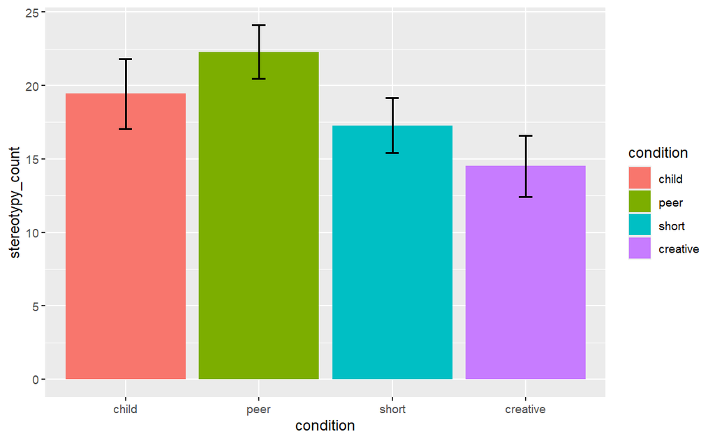

```r
# Plots for average count and proportion stereotypy for each condition
ggplot(stereotypy_ssonly, aes(x = condition, y = stereotypy_count, fill = condition)) +
  stat_summary(aes(y = stereotypy_count), fun = "mean", geom = "bar") +
  stat_summary(fun.data = mean_cl_normal, geom = "errorbar", width = .1, linewidth = .75)
```

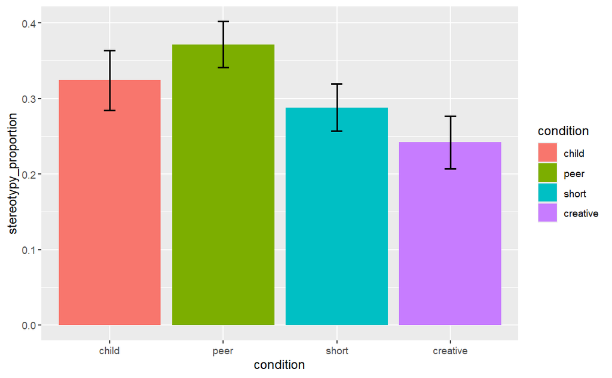

```r
ggplot(stereotypy_ssonly, aes(x = condition, y = stereotypy_proportion, fill = condition)) +
  stat_summary(aes(y = stereotypy_proportion), fun = "mean", geom = "bar") +
  stat_summary(fun.data = mean_cl_normal, geom = "errorbar", width = .1, linewidth = .75)
```

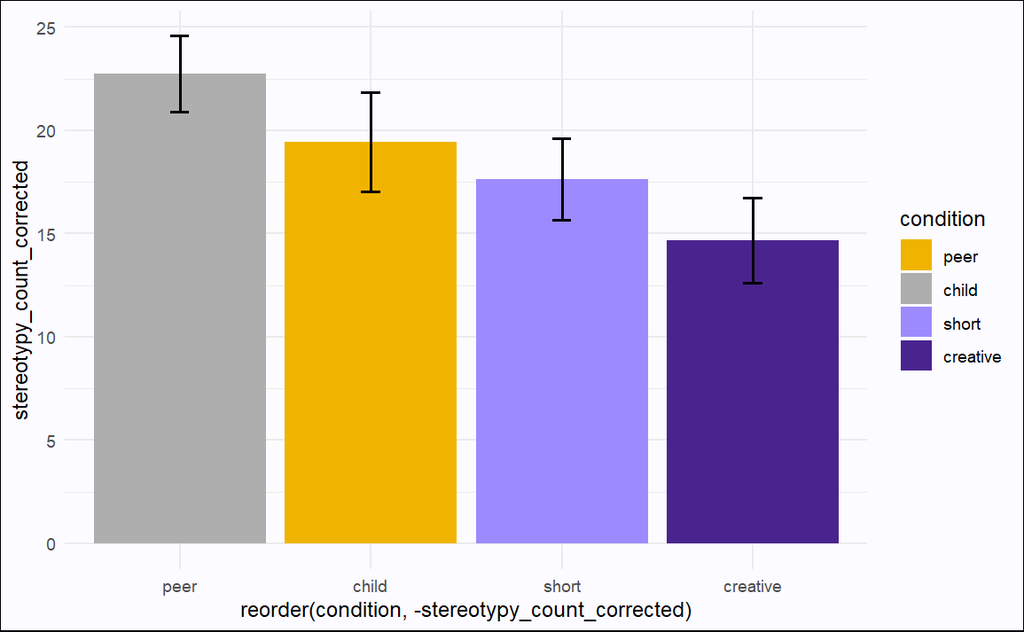

```r
# Plot for average corrected stereotypy count for each condition
ggplot(stereotypy_ssonly_corrected, aes(x = reorder(condition, -stereotypy_count_corrected), y = stereotypy_count_corrected, fill = condition)) +
  stat_summary(aes(y = stereotypy_count_corrected), fun = "mean", geom = "bar") +
  stat_summary(fun.data = mean_cl_normal, geom = "errorbar", width = .1, linewidth = .75) +
  theme_minimal() +
  scale_fill_manual(labels = c("peer", "child", "short", "creative") ,
                                    values = c("#f0b400","#AEAEAE", "#9C8BFF", "#4A248E"))+
  theme(plot.background = element_rect(fill = "#FCFBFF"))
```